# Part 1:

# Part 3

## • DOMAIN: Startup ecosystem

• CONTEXT: Company X is a EU online publisher focusing on the startups industry. The company specifically reports on the business related to technology news, analysis of emerging trends and profiling of new tech businesses and products. Their event i.e. Startup Battlefield is the world’s pre-eminent startup competition. Startup Battlefield features 15-30 top early stage startups pitching top judges in front of a vast live audience, present in person and online.

• DATA DESCRIPTION: CompanyX_EU.csv - Each row in the dataset is a Start-up company and the columns describe the company. ATTRIBUTE

INFORMATION:

1. Startup: Name of the company
2. Product: Actual product
3. Funding: Funds raised by the company in USD
4. Event: The event the company participated in
5. Result: Described by Contestant, Finalist, Audience choice, Winner or Runner up
6. OperatingState: Current status of the company, Operating ,Closed, Acquired or IPO

*Dataset has been downloaded from the internet. All the credit for the dataset goes to the original creator of the data.

• PROJECT OBJECTIVE: Analyse the data of the various companies from the given dataset and perform the tasks that are specified in the below steps. Draw insights from the various attributes that are present in the dataset, plot distributions, state hypotheses and draw conclusions from the dataset.

```python
import numpy as np
import pandas as pd
import seaborn as sns
import matplotlib.pyplot as plt  # seaborn is based on matplotlib
sns.set(color_codes=True) # adds a nice background to the graphs
%matplotlib inline
```

====================================================================================================================

### 3.1.1: Read the CSV file.

```python
eco=pd.read_csv('DS - Part3 - CompanyX_EU.csv')
```

```python
eco.head()
```

|  | Startup | Product | Funding | Event | Result | OperatingState |
| --- | --- | --- | --- | --- | --- | --- |
| 0 | 2600Hz | 2600hz.com | NaN | Disrupt SF 2013 | Contestant | Operating |
| 1 | 3DLT | 3dlt.com | $630K | Disrupt NYC 2013 | Contestant | Closed |
| 2 | 3DPrinterOS | 3dprinteros.com | NaN | Disrupt SF 2016 | Contestant | Operating |
| 3 | 3Dprintler | 3dprintler.com | $1M | Disrupt NY 2016 | Audience choice | Operating |
| 4 | 42 Technologies | 42technologies.com | NaN | Disrupt NYC 2013 | Contestant | Operating |

=====================================================================================================================

### 3.2.1: Check the datatypes of each attribute.

```python
# Check the datatype of each attribute
eco.info()
```

```
<class 'pandas.core.frame.DataFrame'>
RangeIndex: 662 entries, 0 to 661
Data columns (total 6 columns):
 #   Column          Non-Null Count  Dtype
---  ------          --------------  -----
 0   Startup         662 non-null    object
 1   Product         656 non-null    object
 2   Funding         448 non-null    object
 3   Event           662 non-null    object
 4   Result          662 non-null    object
 5   OperatingState  662 non-null    object
dtypes: object(6)
memory usage: 31.2+ KB
```

```python
# We can see that the Datatype of all the coulmns is Object
```

```python
# Describe the Eco dataframe
eco.describe(include="all")
```

|  | Startup | Product | Funding | Event | Result | OperatingState |
| --- | --- | --- | --- | --- | --- | --- |
| count | 662 | 656 | 448 | 662 | 662 | 662 |
| unique | 662 | 656 | 240 | 26 | 5 | 4 |
| top | LearnVest | healthcrew.me | $1M | TC50 2008 | Contestant | Operating |
| freq | 1 | 1 | 17 | 52 | 488 | 465 |

```python
# Another way so checking the datatype where the datatype is stored in the column of a dataframe
```

```python
eco.dtypes.to_frame(name = 'Data Type')
```

|  | Data Type |
| --- | --- |
| Startup | object |
| Product | object |
| Funding | object |
| Event | object |
| Result | object |
| OperatingState | object |

```python
# Above dataframe shows the datatypes of the coloumns in an better way
```

=====================================================================================================================

### 3.2.2 - Check for null values in the attributes.

```python
# Is any of the values in columns of the eco are null
eco.isnull().any()
```

```
Startup           False
Product            True
Funding            True
Event             False
Result            False
OperatingState    False
dtype: bool
```

```python
# From above we can see that product and funding have some NULL values
```

```python
# To check what are the number of NULL values
eco.isnull().sum()
```

```
Startup             0
Product             6
Funding           214
Event               0
Result              0
OperatingState      0
dtype: int64
```

```python
# From above we can see that product column have 6 NULLS and Funding colmn have 214 NULLS
```

```python
null_cols = eco.columns[eco.isnull().any()]
null_cols
```

```
Index(['Product', 'Funding'], dtype='object')
```

```python
# Below shows the rows where NULLS are present in Product
# one more nsight - we can see that there are 4 rows which are common to product and Funding
eco[eco.Product.isnull()]
```

|  | Startup | Product | Funding | Event | Result | OperatingState |
| --- | --- | --- | --- | --- | --- | --- |
| 257 | IMO | NaN | NaN | TC50 2009 | Contestant | Operating |
| 286 | keenkong | NaN | NaN | Disrupt NYC 2010 | Contestant | Operating |
| 318 | LocalHero Inc. | NaN | NaN | Disrupt SF 2011 | Contestant | Operating |
| 359 | MotherKnows | NaN | NaN | Disrupt NYC 2011 | Contestant | Operating |
| 445 | Rainbow | NaN | $3.3M | Disrupt SF 2013 | Contestant | Operating |
| 565 | Tello Applications | NaN | $4.7M | Disrupt SF 2010 | Contestant | Closed |

```python
# Below shows the rows where NULLS are present in Funding
eco[eco.Funding.isnull()]
```

|  | Startup | Product | Funding | Event | Result | OperatingState |
| --- | --- | --- | --- | --- | --- | --- |
| 0 | 2600Hz | 2600hz.com | NaN | Disrupt SF 2013 | Contestant | Operating |
| 2 | 3DPrinterOS | 3dprinteros.com | NaN | Disrupt SF 2016 | Contestant | Operating |
| 4 | 42 Technologies | 42technologies.com | NaN | Disrupt NYC 2013 | Contestant | Operating |
| 7 | 8020 Media | 8020media.com | NaN | TC40 2007 | Contestant | Operating |
| 8 | About Last Night | aboutlastnight.net | NaN | Disrupt NYC 2012 | Contestant | Operating |
| ... | ... | ... | ... | ... | ... | ... |
| 648 | YOOBIC | yoobic.com | NaN | Disrupt London 2015 | Finalist | Operating |
| 651 | YourVersion | yourversion.com | NaN | TC50 2009 | Audience choice | Operating |
| 652 | Yuwan | iyuwan.cn | NaN | Disrupt Beijing 2011 | Contestant | Closed |
| 653 | ZAP! | zapreklam.com/ | NaN | Disrupt EU 2014 | Audience choice | Operating |
| 655 | Zello | zello.com | NaN | TC40 2007 | Contestant | Operating |

214 rows × 6 columns

====================================================================================================================

### 3.3.1 : Drop the null values

```python
#Dropping the null values and storing the data into new Data frame i.e. eco_dropped
eco_dropped = eco.dropna()
```

```python
# Check what is the info about the new Data frame i.e. eco_dropped
eco_dropped.info()
```

```
<class 'pandas.core.frame.DataFrame'>
Int64Index: 446 entries, 1 to 661
Data columns (total 6 columns):
 #   Column          Non-Null Count  Dtype
---  ------          --------------  -----
 0   Startup         446 non-null    object
 1   Product         446 non-null    object
 2   Funding         446 non-null    object
 3   Event           446 non-null    object
 4   Result          446 non-null    object
 5   OperatingState  446 non-null    object
dtypes: object(6)
memory usage: 24.4+ KB
```

```python
#Check the shape of the new Data frame i.e. eco_dropped
eco_dropped.shape
```

```
(446, 6)
```

```python
# As part of this, We can see that after remobing the NULL rows we are left with 446 rows
# No of in the New data frame are 446
# No of rows which are dropped are 216 (214 rows from Funding including the 4 rows which were already part of the product,
#                                        2 unique rows from Product)
```

==================================================================================================================

# 3.3.2 : Convert the ‘Funding’ features to a numerical value

```python
eco_dropped.head()
```

|  | Startup | Product | Funding | Event | Result | OperatingState |
| --- | --- | --- | --- | --- | --- | --- |
| 1 | 3DLT | 3dlt.com | $630K | Disrupt NYC 2013 | Contestant | Closed |
| 3 | 3Dprintler | 3dprintler.com | $1M | Disrupt NY 2016 | Audience choice | Operating |
| 5 | 5to1 | 5to1.com | $19.3M | TC50 2009 | Contestant | Acquired |
| 6 | 8 Securities | 8securities.com | $29M | Disrupt Beijing 2011 | Finalist | Operating |
| 10 | AdhereTech | adheretech.com | $1.8M | Hardware Battlefield 2014 | Contestant | Operating |

```python
# Created a funding_num function to convert the data into Millions
def funding_num(x):
    x= x.replace('$','')
    if 'K' in x:
        x=x.replace('K','')
        return float(x)*1000/1000000
    elif 'M' in x:
        x=x.replace('M','')
        return float(x)*1000000/1000000
    elif 'B'in x:
        x=x.replace('B','')
        return float(x)*1000
```

```python
# Applying the funding_num function to Funding column of eco_dropped Data frame
eco_dropped.Funding = eco_dropped.Funding.apply(funding_num)
```

[output not shown]

```python
eco_dropped.head()
```

|  | Startup | Product | Funding | Event | Result | OperatingState |
| --- | --- | --- | --- | --- | --- | --- |
| 1 | 3DLT | 3dlt.com | 0.63 | Disrupt NYC 2013 | Contestant | Closed |
| 3 | 3Dprintler | 3dprintler.com | 1.00 | Disrupt NY 2016 | Audience choice | Operating |
| 5 | 5to1 | 5to1.com | 19.30 | TC50 2009 | Contestant | Acquired |
| 6 | 8 Securities | 8securities.com | 29.00 | Disrupt Beijing 2011 | Finalist | Operating |
| 10 | AdhereTech | adheretech.com | 1.80 | Hardware Battlefield 2014 | Contestant | Operating |

```python
eco_dropped.info()
```

```
<class 'pandas.core.frame.DataFrame'>
Int64Index: 446 entries, 1 to 661
Data columns (total 6 columns):
 #   Column          Non-Null Count  Dtype
---  ------          --------------  -----
 0   Startup         446 non-null    object
 1   Product         446 non-null    object
 2   Funding         446 non-null    float64
 3   Event           446 non-null    object
 4   Result          446 non-null    object
 5   OperatingState  446 non-null    object
dtypes: float64(1), object(5)
memory usage: 24.4+ KB
```

```python
# From Above Info command we can see that Funding column is converted into Numeric and data is converted into Millions
```

```python
# Changing the column name from 'Funding' to 'Funding in Millions' to clearly show that data is in millions
eco_dropped.rename( columns = {'Funding':'Funding_in_Millions'},inplace=True)
```

[output not shown]

```python
eco_dropped.info()
```

```
<class 'pandas.core.frame.DataFrame'>
Int64Index: 446 entries, 1 to 661
Data columns (total 6 columns):
 #   Column               Non-Null Count  Dtype
---  ------               --------------  -----
 0   Startup              446 non-null    object
 1   Product              446 non-null    object
 2   Funding_in_Millions  446 non-null    float64
 3   Event                446 non-null    object
 4   Result               446 non-null    object
 5   OperatingState       446 non-null    object
dtypes: float64(1), object(5)
memory usage: 24.4+ KB
```

======================================================================================================================

### 3.3.3 : Plot box plot for funds in million

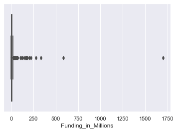

```python
sns.boxplot(eco_dropped['Funding_in_Millions']);
```

```python
# From Box plot, We can see that there are many outliers
```

```python
eco_dropped['Funding_in_Millions'].describe()
# From below details,
# it is clearly visible that Funding_in_Millions is right skeyed. Mean and mediun are far away from the Max value
```

```
count     446.000000
mean       17.241489
std        90.483710
min         0.005000
25%         0.745250
50%         2.200000
75%         9.475000
max      1700.000000
Name: Funding_in_Millions, dtype: float64
```

===================================================================================================================

### 3.3.4 : Get the lower fence from the box plot

```python
eco_dropped.Funding_in_Millions.describe()
```

```
count     446.000000
mean       17.241489
std        90.483710
min         0.005000
25%         0.745250
50%         2.200000
75%         9.475000
max      1700.000000
Name: Funding_in_Millions, dtype: float64
```

```python
# Basis on the Min, Q1, Q2, Q3 and Max value,  it is clearly visible that data is Right skeyed
```

```python
# Funding_IQR =
Funding_Q1 = eco_dropped.Funding_in_Millions.describe()[4]
# it can be also derived from
# Fudning_Q1 = eco_dropped["Funding_in_Millions"].quantile(0.25)
Funding_Q3 = eco_dropped.Funding_in_Millions.describe()[6]
# it can be also derived from
# Fudning_Q3 = eco_dropped["Funding_in_Millions"].quantile(0.75)
Funding_IQR = Funding_Q3-Funding_Q1
```

```python
print(eco_dropped["Funding_in_Millions"].quantile(0.25))
print(eco_dropped["Funding_in_Millions"].quantile(0.75))
```

```
0.74525
9.475
```

```python
# Lower Fence and Upper fence
Upper_Fence = Funding_Q3 + (1.5 * Funding_IQR)
Lower_Fence = Funding_Q1 - (1.5 * Funding_IQR)
```

```python
print(Upper_Fence)
```

```
22.569625
```

```python
#Lower fence for the dataframe
print(Lower_Fence)
```

```
-12.349374999999998
```

```python
eco_dropped_lower = eco_dropped[eco_dropped['Funding_in_Millions'] < Lower_Fence]
eco_dropped_lower
```

|  | Startup | Product | Funding_in_Millions | Event | Result | OperatingState |
| --- | --- | --- | --- | --- | --- | --- |

```python
eco_dropped_lower.count()
```

```
Startup                0
Product                0
Funding_in_Millions    0
Event                  0
Result                 0
OperatingState         0
dtype: int64
```

```python
# From above , we can see that there are no items lowere than the lower fence
```

### 3.3.5 - Check number of outliers greater than upper fence

```python
eco_dropped_upper = eco_dropped[eco_dropped['Funding_in_Millions'] > Upper_Fence]
eco_dropped_upper
# Below are the outliers greater than upper fence
```

|  | Startup | Product | Funding_in_Millions | Event | Result | OperatingState |
| --- | --- | --- | --- | --- | --- | --- |
| 6 | 8 Securities | 8securities.com | 29.0 | Disrupt Beijing 2011 | Finalist | Operating |
| 31 | Anyclip | anyclip.com | 24.0 | TC50 2009 | Finalist | Operating |
| 40 | Artsy | artsy.net | 50.9 | Disrupt NYC 2010 | Contestant | Operating |
| 49 | Badgeville | badgeville.com | 40.0 | Disrupt SF 2010 | Finalist | Acquired |
| 56 | Betterment | betterment.com | 205.0 | Disrupt NYC 2010 | Finalist | Operating |
| 108 | Clickable | clickable.com | 32.5 | TC40 2007 | Finalist | Acquired |
| 113 | Cloudflare | cloudflare.com | 182.1 | Disrupt SF 2010 | Runner up | Operating |
| 128 | Credit Sesame | creditsesame.com | 35.4 | Disrupt SF 2010 | Contestant | Operating |
| 130 | CrowdFlower Inc. | crowdflower.com | 38.0 | TC50 2009 | Contestant | Operating |
| 132 | Cubic Telecom | cubictelecom.com | 37.1 | TC40 2007 | Contestant | Operating |
| 138 | DataSift | datasift.com | 72.0 | Disrupt SF 2010 | Finalist | Operating |
| 139 | DataXu | dataxu.com | 64.0 | TC50 2009 | Contestant | Operating |
| 154 | Dropbox | dropbox.com | 1700.0 | TC50 2008 | Contestant | Operating |
| 166 | Enigma | enigma.io | 34.6 | Disrupt NYC 2013 | Winner | Operating |
| 172 | EverythingMe | everything.me | 35.5 | Disrupt NYC 2011 | Contestant | Closed |
| 179 | Famo.us | famo.us | 30.1 | Disrupt SF 2012 | Contestant | Operating |
| 180 | Farmigo | farmigo.com | 26.0 | Disrupt SF 2011 | Finalist | Operating |
| 188 | Fitbit | fitbit.com | 66.0 | TC50 2008 | Finalist | Ipo |
| 191 | Flock | flock.com | 28.3 | TC40 2007 | Contestant | Acquired |
| 209 | Getaround | getaround.com | 103.0 | Disrupt NYC 2011 | Winner | Operating |
| 213 | Gild | gild.com | 25.9 | Disrupt SF 2010 | Contestant | Acquired |
| 215 | Glide | glide.me | 36.5 | Disrupt NYC 2013 | Audience choice | Operating |
| 225 | Grockit | grockit.com | 44.7 | TC50 2008 | Finalist | Acquired |
| 231 | HackerRank | hackerrank.com | 24.2 | Disrupt SF 2012 | Contestant | Operating |
| 271 | Ionic Security | ionicsecurity.com | 122.4 | Disrupt SF 2012 | Contestant | Operating |
| 276 | IZEA | izea.com | 34.9 | Disrupt NYC 2010 | Contestant | Ipo |
| 279 | Jiff | jiff.com | 67.8 | Disrupt SF 2011 | Contestant | Acquired |
| 282 | Kaltura | kaltura.com | 166.1 | TC40 2007 | Audience choice | Operating |
| 302 | Layer | layer.com | 42.1 | Disrupt SF 2013 | Winner | Operating |
| 305 | LearnVest | learnvest.com | 69.0 | TC50 2009 | Contestant | Acquired |
| 313 | LiveIntent | liveintent.com | 65.1 | Disrupt NYC 2010 | Audience choice | Operating |
| 325 | Lystable | lystable.com | 25.1 | Disrupt London 2015 | Finalist | Operating |
| 346 | Mint | mint.com | 31.8 | TC40 2007 | Winner | Acquired |
| 389 | OrderWithMe | orderwithme.com | 37.0 | Disrupt Beijing 2011 | Winner | Operating |
| 393 | Osmo | playosmo.com | 38.5 | Disrupt SF 2013 | Contestant | Operating |
| 394 | Ossia | ossia.com | 25.5 | Disrupt SF 2013 | Runner up | Operating |
| 398 | Owlet Baby Care | owletcare.com | 24.0 | Hardware Battlefield 2014 | Runner up | Operating |
| 427 | Postmates | postmates.com | 278.0 | Disrupt SF 2011 | Contestant | Operating |
| 432 | Prism Skylabs | prism.com | 24.0 | Disrupt SF 2011 | Runner up | Operating |
| 435 | PubMatic | pubmatic.com | 63.0 | TC40 2007 | Contestant | Operating |
| 460 | Roadie | roadie.com | 25.0 | Disrupt NYC 2014 | Audience choice | Operating |
| 471 | SeatGeek | seatgeek.com | 160.0 | TC50 2009 | Contestant | Operating |
| 546 | StyleSeat | styleseat.com | 40.0 | Disrupt NYC 2011 | Contestant | Operating |
| 555 | Symphony Commerce | symphonycommerce.com | 47.4 | Disrupt NYC 2011 | Contestant | Operating |
| 560 | Talkdesk | talkdesk.com | 24.5 | Disrupt NYC 2012 | Contestant | Operating |
| 581 | TouchPal | touchpal.com | 25.0 | Disrupt Beijing 2011 | Finalist | Operating |
| 593 | TrueCar | truecar.com | 332.4 | TC50 2008 | Contestant | Ipo |
| 598 | UberConference | uberconference.com | 35.0 | Disrupt NYC 2012 | Winner | Operating |
| 606 | Upwork | upwork.com | 168.8 | TC50 2009 | Audience choice | Operating |
| 615 | VideoSurf | videosurf.com | 28.0 | TC50 2008 | Contestant | Acquired |
| 625 | Voxy | voxy.com | 30.8 | Disrupt SF 2010 | Contestant | Operating |
| 643 | Xobni | yahoo.com | 41.8 | TC40 2007 | Contestant | Acquired |
| 644 | Yammer | yammer.com | 142.0 | TC50 2008 | Winner | Acquired |
| 647 | Yext | yext.com | 117.8 | TC50 2009 | Contestant | Ipo |
| 649 | YouNow | younow.com | 26.0 | Disrupt SF 2011 | Contestant | Operating |
| 650 | YourMechanic | yourmechanic.com | 28.0 | Disrupt SF 2012 | Winner | Operating |
| 654 | ZEFR | zefr.com | 62.1 | Disrupt NYC 2010 | Contestant | Operating |
| 656 | Zenefits | zenefits.com | 583.6 | Disrupt NYC 2013 | Finalist | Operating |
| 659 | Zocdoc | zocdoc.com | 223.0 | TC40 2007 | Contestant | Operating |
| 661 | Zumper | zumper.com | 31.5 | Disrupt SF 2012 | Finalist | Operating |

```python
eco_dropped_upper.info()
```

```
<class 'pandas.core.frame.DataFrame'>
Int64Index: 60 entries, 6 to 661
Data columns (total 6 columns):
 #   Column               Non-Null Count  Dtype
---  ------               --------------  -----
 0   Startup              60 non-null     object
 1   Product              60 non-null     object
 2   Funding_in_Millions  60 non-null     float64
 3   Event                60 non-null     object
 4   Result               60 non-null     object
 5   OperatingState       60 non-null     object
dtypes: float64(1), object(5)
memory usage: 3.3+ KB
```

```python
eco_dropped_upper.count()
```

```
Startup                60
Product                60
Funding_in_Millions    60
Event                  60
Result                 60
OperatingState         60
dtype: int64
```

```python
# Above information clearly shows that there are 60 Outliers greater than the upper fence
```

### 3.3.6 - Drop the values that are greater than upper fence

```python
# Creating a new data frame whcih will have the values are lower than the Upper fence
# i.e. 60 outliers should be dropped from the total 446 rows
# 446-60 = 386 rows should be present int he new dataframe
```

```python
eco_dropped_final = eco_dropped[eco_dropped['Funding_in_Millions'] <= Upper_Fence]
eco_dropped_final
```

|  | Startup | Product | Funding_in_Millions | Event | Result | OperatingState |
| --- | --- | --- | --- | --- | --- | --- |
| 1 | 3DLT | 3dlt.com | 0.63 | Disrupt NYC 2013 | Contestant | Closed |
| 3 | 3Dprintler | 3dprintler.com | 1.00 | Disrupt NY 2016 | Audience choice | Operating |
| 5 | 5to1 | 5to1.com | 19.30 | TC50 2009 | Contestant | Acquired |
| 10 | AdhereTech | adheretech.com | 1.80 | Hardware Battlefield 2014 | Contestant | Operating |
| 11 | AdRocket | adrocket.com | 1.00 | TC50 2008 | Contestant | Closed |
| ... | ... | ... | ... | ... | ... | ... |
| 645 | Yap | yapme.com | 10.00 | TC40 2007 | Contestant | Closed |
| 646 | YayPay Inc | yaypay.com | 0.90 | Disrupt London 2015 | Contestant | Operating |
| 657 | Zivity | zivity.com | 8.00 | TC40 2007 | Contestant | Operating |
| 658 | Zmorph | zmorph3d.com | 1.00 | - | Audience choice | Operating |
| 660 | Zula | zulaapp.com | 3.40 | Disrupt SF 2013 | Audience choice | Operating |

386 rows × 6 columns

```python
eco_dropped_final.info()
```

```
<class 'pandas.core.frame.DataFrame'>
Int64Index: 386 entries, 1 to 660
Data columns (total 6 columns):
 #   Column               Non-Null Count  Dtype
---  ------               --------------  -----
 0   Startup              386 non-null    object
 1   Product              386 non-null    object
 2   Funding_in_Millions  386 non-null    float64
 3   Event                386 non-null    object
 4   Result               386 non-null    object
 5   OperatingState       386 non-null    object
dtypes: float64(1), object(5)
memory usage: 21.1+ KB
```

```python
#Above information clearly shows that 386 rows are present in new dataframe
```

========================================================================================================================

### 3.3.7 - Plot the box plot after dropping the values

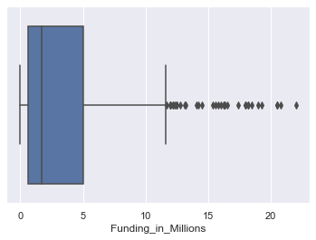

```python
sns.boxplot(eco_dropped_final['Funding_in_Millions']);
```

```python
# Above box plot of new data frame (i.e. eco_dropped_1) shows that there are outliers for this data frame too
```

======================================================================================================================

### 3.3.8 - Check frequency of the OperatingState features classes

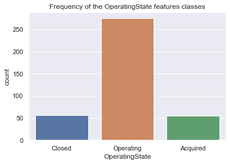

```python
sns.countplot(eco_dropped_final.OperatingState);
plt.title('Frequency of the OperatingState features classes')
```

```python
# Same can be displayed with the help of Histpgram
```

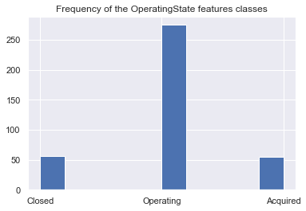

```python
eco_dropped_final.OperatingState.hist();
plt.title('Frequency of the OperatingState features classes')
```

```python
# Just to check the no of start-ups which are Operating, Closed and Acuired
eco_dropped_final.OperatingState.value_counts()
```

```
Operating    275
Closed        56
Acquired      55
Name: OperatingState, dtype: int64
```

```python
# As per above graph,
# it is visible that 275 out of 386 startups are currenlty operating which is way more than the Closed and acquired
```

=======================================================================================================================

### 3.3.9 - Plot a distribution plot for Funds in million

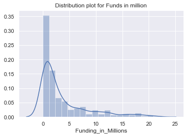

```python
sns.distplot(eco_dropped_final.Funding_in_Millions);
plt.title('Distribution plot for Funds in million')
```

=====================================================================================================================

### 3.3.9. - Plot distribution plots for companies still operating and companies that closed

```
array([[<matplotlib.axes._subplots.AxesSubplot object at 0x000001774D3656C8>,
      dtype=object)
```

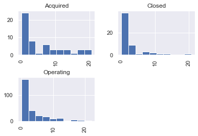

```python
eco_dropped_final.hist(by = 'OperatingState')
```

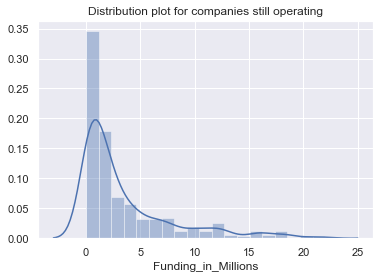

```python
# Plot distribution plots for companies still operating
sns.distplot(eco_dropped_final[eco_dropped_final.OperatingState == 'Operating']['Funding_in_Millions'])
plt.title('Distribution plot for companies still operating')
```

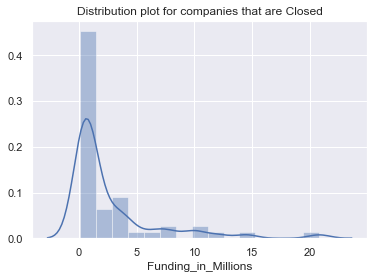

```python
# Plot distribution plots for companies still operating
sns.distplot(eco_dropped_final[eco_dropped_final.OperatingState == 'Closed']['Funding_in_Millions'])
plt.title('Distribution plot for companies that are Closed')
```

======================================================================================================================

# 3.4 - Statistical analysis:

### 3.4.1 - Is there any significant difference between Funds raised by companies that are still operating vs companies that closed down?

```python
Startup_operating_details = eco_dropped_final[eco_dropped_final.OperatingState == 'Operating']['Funding_in_Millions'].describe()
Startup_operating_details
```

```
count    275.000000
mean       3.517953
std        4.430511
min        0.005000
25%        0.578050
50%        1.700000
75%        4.500000
max       22.000000
Name: Funding_in_Millions, dtype: float64
```

```python
Startup_Closed_details = eco_dropped_final[eco_dropped_final.OperatingState == 'Closed']['Funding_in_Millions'].describe()
Startup_Closed_details
```

```
count    56.000000
mean      2.682423
std       4.060193
min       0.093000
25%       0.443750
50%       0.927100
75%       3.125000
max      20.800000
Name: Funding_in_Millions, dtype: float64
```

#### From Above details, It is visible that there is no Significant difference between the Startups that are still operating and startups that are closed

```
For Startup that are closed (56) and for startup that are still operating (275), Below are the details.

Mean of Closed is 2.68 and Mean of Operating is 3.51 || No significant difference
STD of Closed is 4.06 and STD of Operating is 4.43 || No significant difference
Minumum of Closed is 0.09 and Minumum of Operating is 0.005 || No significant difference
Mediun of Closed is 0.92 and Mediun of Operating is 1.7 || No significant difference
Maximum of Closed is 20.80 and Maximum of Operating is 22.00 || No significant difference
```

=================================================================================================================

### 3.4.1.1 - Write the null hypothesis and alternative hypothesis.

### Null Hypothesis

Null Hypothesis (H0) - Funds raised by companies that are still operating = Funds raised by companies that are closed

### Alternate Hypothesis

Alternate Hypothesis (Ha) - Funds raised by companies that are still operating != Funds raised by companies that are closed

##### Alpha is 0.05 and it is two tailed test

====================================================================================================================

### 3.4.1.2. - Test for significance and conclusion

```python
from scipy.stats import ttest_ind

t_stats, p_value = ttest_ind(eco_dropped_final[eco_dropped_final.OperatingState == 'Operating']['Funding_in_Millions'],
                             eco_dropped_final[eco_dropped_final.OperatingState == 'Closed']['Funding_in_Millions'])

print('T Statistic - ' + str(t_stats))
print('P Value - ' + str(p_value))

# Alpha is 0.05

if p_value < 0.05:
    print('We Reject the Null Hypothesis H0 - P value i.e. ' + str(round((p_value),2)) + ' is less than .05')
else:
    print('We fail to Reject the Null Hypothesis H0 - P value i.e. ' + str(round((p_value),2)) + ' is more than .05')
```

```
T Statistic - 1.3039132895334589
P Value - 0.1931747168826862
We fail to Reject the Null Hypothesis H0 - P value i.e. 0.19 is more than .05
```

=================================================================================================================

### 3.4.2 - Make a copy of the original data frame.

```python
eco_copy = eco
```

```python
eco_copy.info()
```

```
<class 'pandas.core.frame.DataFrame'>
RangeIndex: 662 entries, 0 to 661
Data columns (total 6 columns):
 #   Column          Non-Null Count  Dtype
---  ------          --------------  -----
 0   Startup         662 non-null    object
 1   Product         656 non-null    object
 2   Funding         448 non-null    object
 3   Event           662 non-null    object
 4   Result          662 non-null    object
 5   OperatingState  662 non-null    object
dtypes: object(6)
memory usage: 31.2+ KB
```

===================================================================================================================

### 3.4.3. - Check frequency distribution of Result variable

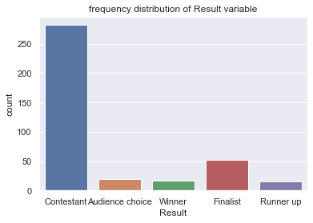

```python
sns.countplot(eco_dropped_final.Result);
plt.title('frequency distribution of Result variable')
```

========================================================================================================================

### 3.4.4. - Calculate percentage of winners that are still operating and percentage of contestants that are still operating

```python
Total_Winner = eco_dropped_final[eco_dropped_final.Result == 'Winner']
Total_Contestant = eco_dropped_final[eco_dropped_final.Result == 'Contestant']
print('Total number of Winners - ' + str(Total_Winner.count().values[0]))
Total_Contestant.count().values[0]
print('Total number of Winners - ' + str(Total_Contestant.count().values[0]))
```

```
Total number of Winners - 17
Total number of Winners - 282
```

```python
Winner_Operating = eco_dropped_final[(eco_dropped_final.Result == 'Winner') & (eco_dropped_final.OperatingState == 'Operating')]
print('Winners that are still Operating - ' + str(Winner_Operating.count().values[0]))
Contestant_Operating = eco_dropped_final[(eco_dropped_final.Result == 'Contestant') & (eco_dropped_final.OperatingState == 'Operating')]
print('Contestants that are still Operating - ' + str(Contestant_Operating.count().values[0]))
```

```
Winners that are still Operating - 12
Contestants that are still Operating - 194
```

```python
Percentage_Winner_Operating = (Winner_Operating.count().values[0] * 100 )/Total_Winner.count().values[0]
print('Percentage of winners that are still operating - ' + str(Percentage_Winner_Operating) + ' %')
```

```
Percentage of winners that are still operating - 70.58823529411765 %
```

```python
Percentage_Contestants_Operating = (Contestant_Operating.count().values[0] * 100 )/Total_Contestant.count().values[0]
print('Percentage of Contestants that are still operating - ' + str(Percentage_Contestants_Operating) + ' %')
```

```
Percentage of Contestants that are still operating - 68.79432624113475 %
```

======================================================================================================================